# NBA Box Score Analysis

### - How have NBA offenses changed over the past 20 years? How is scoring up so much?

### - Which team stats correlate most to winning games, and how has that changed team strategy?

### - How have the players themselves changed, both in their role and physically?

### - What are some exemplary teams and players that define this change?

# Scoring

### Easily the most apparent change over the past 20 seasons is the huge jump in per game scoring.

- Average scoring for the 2004-2005 season was just 97.2 points per game.
- Scoring rose to over 114 points per game for the last two seasons, an increase of 17 ppg, or 17.5%!
- Increase in scoring accelerated over the last decade (2014 - 2024) after only increasing slightly from 2004 - 2014
- Low in scoring occured in the lockout shortened 2011 - 2012 season (96.3 ppg), however this could be an outlier due to the difficulty of scoring in a compressed season with little rest and a short training camp.

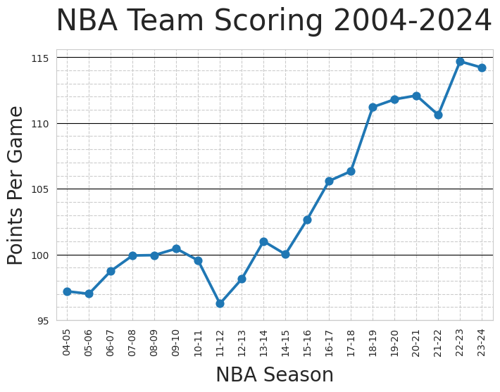

# How has scoring increased?

### Are teams just playing quicker and taking more shots?

- Total shot attempts have risen steadily and significantly over the years
- 80.3 FGA per game in 2004, rising to 88.9 FGA, an increase of 8.6 shots per game, or about 10%
- This does not fully explain 17% increase in scoring.
- In addition, free throws made per game, which are points scored without adding to the field goal attempt totals, are down from 19.7 in 04-05 to 17.0 in 23-24

### So where are the extra points coming from?

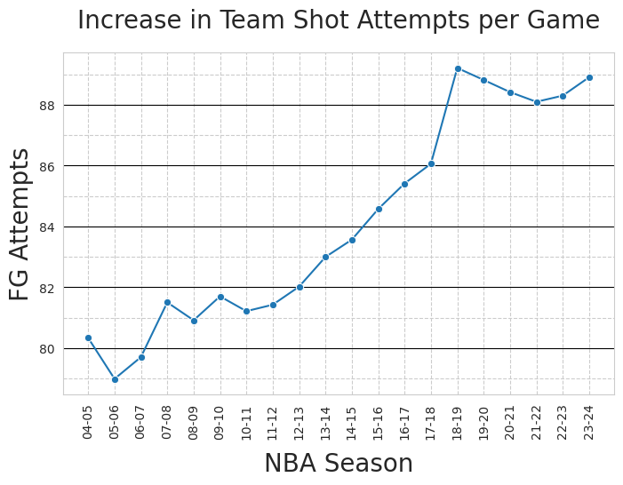

# Team Shot 'Diet'

### Three point attempts vs. Two point attempts

- Teams have gone from 64.6 two point attempts per game down to only 53.8.
- Three point attempts have more than doubled, from 15.8 attempts to over 35.1 per game.
- Three pointers as a percent of total shots has gone from only 19.6% up to 39.5%

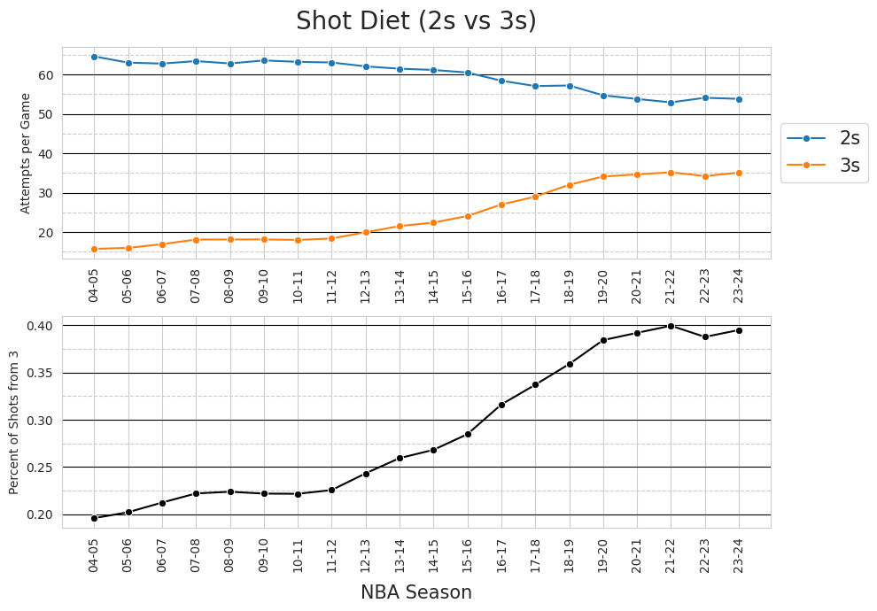

# Better Shooting

### 2 Point Percentage up from .470 to .545

- Increase of 16%!

### 3 Point Percentage up from .355 to .365

- Not as much of an increase, but on more than twice as many attempts. Volume of shots increased, presumably meaning that teams were less selective in which 3 point shots to take. Even with a higher volume, the percentage of makes still went up.

### Overall Shooting Percentage up from .448 to .474

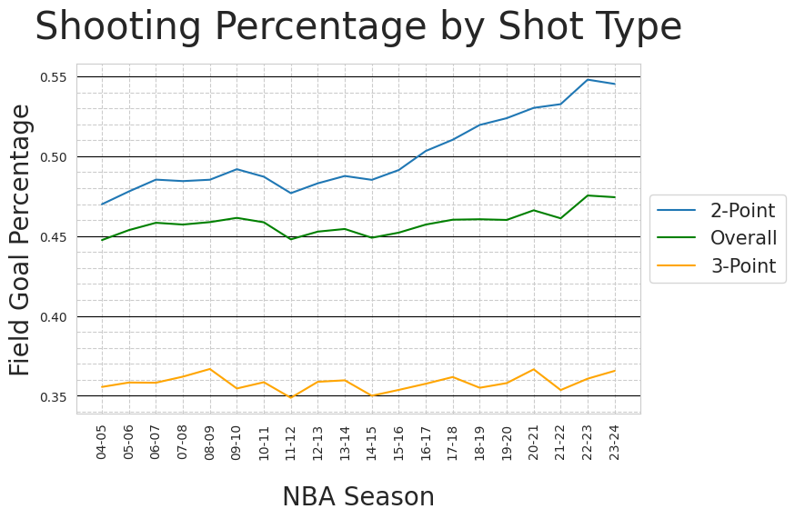

# Efficiency

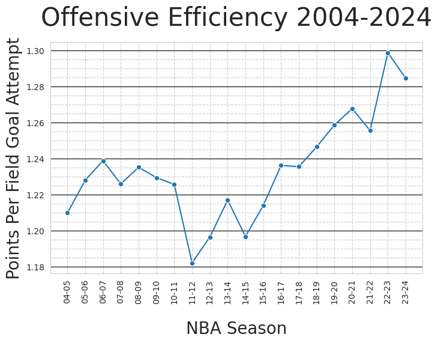

# Efficiency --> Winning

### Unsurprisingly, offensive efficiency (PTS/FGA) is highly correlated with winning

- For most years from 2002-2024, efficiency more correlated with winning than total points scored
- It is significantly more correlated to winning than total shots made (FG)
- Teams with an efficiency more than 0.05 above league average have won 65.4% of their games, equivalent to a 53 win season

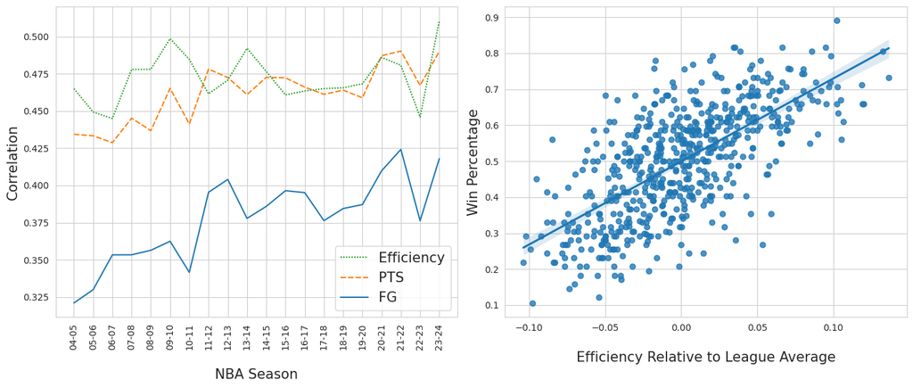

```
Win% Teams With Efficiency Above League Average: 0.582
Win% Teams With Efficiency of 0.05 or more Above League Average: 0.654
Win% Teams With Efficiency of 0.075 Above League Average: 0.696
```

# The Chase for Efficiency

### When we look at shot selection through the eyes of efficiency, we see how and why NBA offensive strategy has changed:

- PTS/2FGA (two point efficiency) was for a long time much lower than PTS/3FGA (three point efficiency)
- Chasing efficiency, 2FGA were traded for more valuable 3FGA
- With teams more selective in their 2FGA, two point efficiency increased.
- In last few years the difference has vanished, and now each shot is equally efficient, suggesting that the current shot diet is the one which gives optimal efficiency

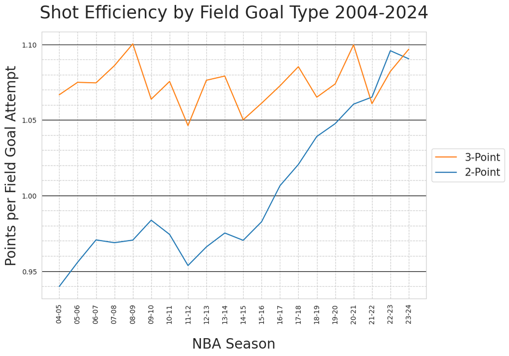

# Team Recap

- NBA Offensive Pace has increased, with teams now avaraging 10% more shots
- In an effort to gain efficiency, which drives wins, teams have traded some less efficient 2 Point attempts for 3 Point attempts
- Overall points per field goal attempt has increased from around 1.2 a decade ago to close to 1.3 today
- Evolution largely begins in 2011-12 season and has continued to the present

# Player Evolution 2011-2024

### How have players changed in conjunction with the shift in offensive strategy?

- Who is shooting all these 3s?
- How are positional roles changing or evolving?
- How are players changing physically with a faster pace of play and more floor spacing?

# 3 Point Shooting

### Who is shooting all the 3s? Everyone

- In 11-12 season, 101 players with 15+ games played averaged three 3FGA or more. By 23-24, 224 players did.
- In 11-12 season, 17 players averaged 5 threes taken a year. By 23-24, over 100 did.
- No player from 11-12 until 14-15 averaged over 8 threes a game. In 23-24 alone, 14 did.

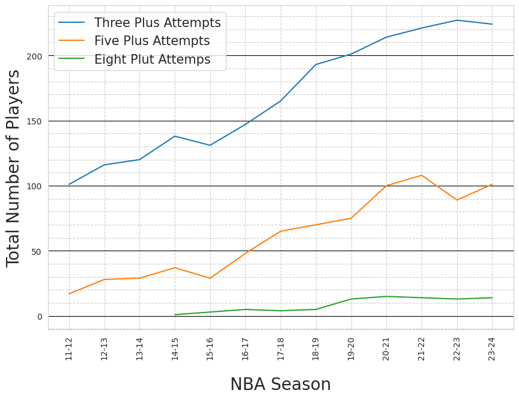

## Centers and Power Forwards shoot well, shoot more

### Since the beginning of the major three point attempt increase in the 11-12 season:

- Power Forwards have increased from 10% of all threes taken to almost 18%
- Centers have gone from almost none (about 1%) taken to 7.5%

### Height and Weight are less negatively correlated with three point percentage today than in 11-12:

- Correlation coefficient for player height and 3FG% went from -0.247 up to -0.116
- Correlation coefficient for player weight and 3FG% went from -0.309 up to -0.123

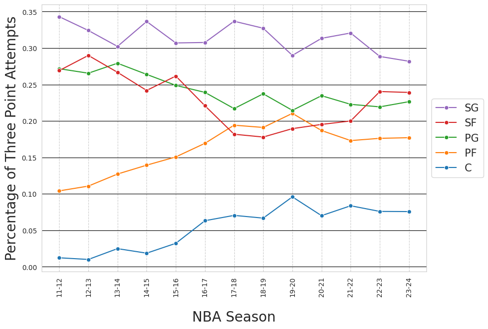

```
Correlation Coefficients for Height in Inches and Weight vs. Three Point Percentage
```

|  | 11-12 | 12-13 | 13-14 | 14-15 | 15-16 | 16-17 | 17-18 | 18-19 | 19-20 | 20-21 | 21-22 | 22-23 | 23-24 |
| --- | --- | --- | --- | --- | --- | --- | --- | --- | --- | --- | --- | --- | --- |
| Height_Inches | -0.246517 | -0.270617 | -0.286226 | -0.187522 | -0.221189 | -0.232912 | -0.127057 | -0.140631 | -0.089345 | -0.194930 | -0.069399 | -0.125146 | -0.115817 |
| Weight | -0.308787 | -0.260454 | -0.302080 | -0.225717 | -0.225193 | -0.186569 | -0.113802 | -0.122526 | -0.052947 | -0.170868 | -0.046927 | -0.065990 | -0.123046 |

# Passing has evolved too

### More Assists, and higher percentage of baskets are assisted

- Assists have gone up from about 21 per game to over 26 per game
- Assist percentage has also increased, from 57% to above 63%
- Teams in 23-24 season averaged 5.13 players with 2.5+ assists per game (minimum 20 games played), compared to only 3.20 in 11-12

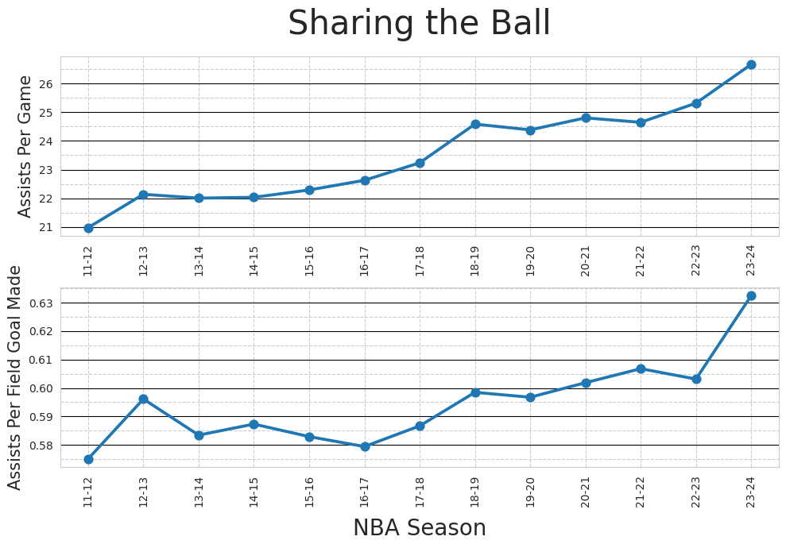

## Assists are being spread around

### Point guards are still the main assistmen, but all positions contribute

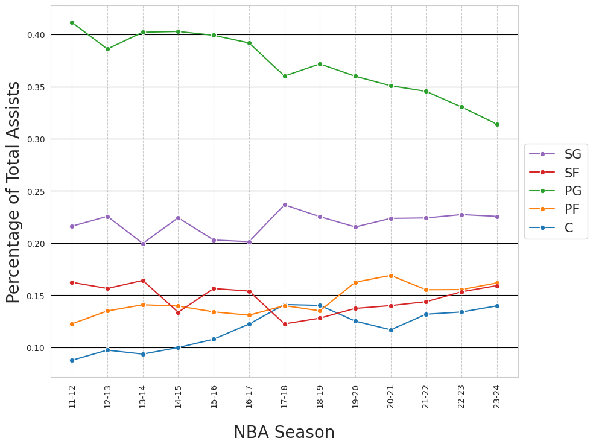

# Different style, different body

### Offensive changes have shifted the physical demands of players

- Players have to keep up with a faster pace as illustrated by increased shots per game
- Players have to 'space the floor' to generate more high value three point attempts
- All positions are more active passers

### Players have thus slimmed down significantly into more lean bodys

- Average BMI of players, weighted by minutes played, has decreased for all positions
- Largest decrease has come from centers and power forwards, whose roles have changed the most

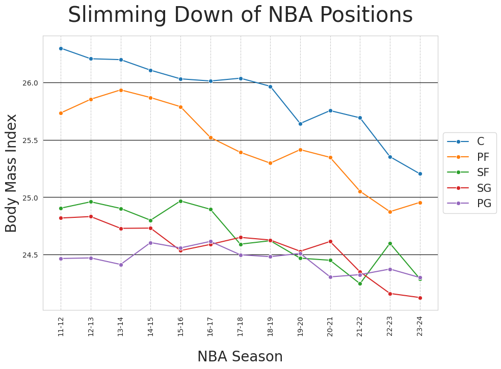

# Other Player Trends

### Top players play fewer minutes, but starters overall average about the same gametime

- Average minutes for the top ten most utilized players decreased from 38.01 in 11-12 to 36.86 in 23-24
- No player has played more than 38 min/game (with more than 20 games played) since 15-16
- Starters' average minutes have held steady around 30-31 min/game for whole 2010-2024 period

### Players overall are slightly younger

- Average age on first day of season of all players is down from 26.55 in 11-12 to 25.76 in 23-24
- Average age when weighted by minutes played (to control for who is actually on the court) is down less, from 26.51 to 26.14
- Median age is down from 26 to 25

# Exemplary Teams/Players

### A few teams pioneered and perfected modern style, leading in 3FGA, AST, and Efficiency

- Phoenix Suns from 2004-2010 and Golden State Warriors from 2014-2019 exemplified these trends.

### Certain players illustrate the new player types we see in today's NBA

- Big men like Nikola Jokic and Draymond Green are now top assist men, while others like Brook Lopez have become three point threats
- Shooters such as Steph Curry and James Harden have leveraged the three point shot to become elite, efficient scorers

## Ahead of Their Time - Phoenix Suns 2004-2010

### Top Efficiency

- Average Efficiency of 0.0806 PTS/FGA above league average (Only 27 teams have averaged better that 0.08 above league average for a single year, while the Suns held this over a six year period)

### Played fast and shared the ball

- Put up 3.43 more field goal attemps than league average
- Assisted 60.3% of made field goals when league average was only 57.7%

### Lots of 3s from lots of places

- Averaged 22.5 three point attempts per game when league average was only 17.2
- Averaged 5 players with 3 or more three point attempts per game, when league average was only 3 (min 20 games played)

### Early version of big man offensive hub - Boris Diaw

- Averaged 6.2 assists in 05-06 even though he came off the bench

## Gold Standard - Golden State Warriors 2014-2019

### Top Efficiency

- Averaged an efficiency of 0.085 above league average, never dropping below 0.064 above league average for a single season
- Average win percentage of 0.785 over 5 year period

### Three point shooting became league standard

- Averaged 30.6 3FGA per game
- From 2014-16, the first two years of the five year period, shot 6.1 more threes than league average
- From 2017-19, the last two years of the period, shot only 1.2 more threes than league average

### Great Passing

- 5.4 assists per game more than league average
- Average of 5 different players with at least 2.5 assists (min 20 games played), while the league averagaed under 4
- Led in assists by PF Draymond Green, with 7.15 assists per game from 15-19

## Exemplary Players

### Big Man Creaters

- No center had averaged 6 or more assists per game until Nikola Jokic in 17-18. He has now done so in 7 straight years
- No power forward other than Boris Diaw had averaged 6 assists until Lebron James in 12-13. Draymond Green has now done it 8 times

### Shooters

- No player before Steph Curry in 15-16 had averaged 10 three point attempts per game. He has now done it six times, averaging a yearly average of 28.45 points per game and 1.42 points per shot attempt
- In five years with at least 9 three point attempts per game, James Harden averaged a yearly average of 30.94 points per game and 1.51 points per shot attempt

### Adapting to the times

- Center Brook Lopez never shot more than 0.2 threes per game from the 08-09 season until the 15-16 season. In every season since, he has shot at least 4 per game

# Conclusion

### NBA Box Score/Roster Statistics illustrate how the game has changed

- Teams play faster, shoot more 3 pointers, and share the ball more
- The search for offensive efficiency has driven this trend, and in the last few years the optimal shot selection has been reached
- All positions contribute to shooting and assisting, with the emergence of the big man shooter/passer a pronounced change
- Players have slimmed down to adapt to a faster pace with more floor spacing